```python
from qiskit import QuantumCircuit, QuantumRegister, ClassicalRegister, transpile
from qiskit_aer import AerSimulator
from qiskit.quantum_info import Statevector, SparsePauliOp
from qiskit.visualization import plot_histogram, plot_bloch_multivector
import numpy as np
```

# **1. Quantum Fourier transform (QFT)**

QFT is the first algorithm you need to understand before reaching quantum phase estimation (QPE). It's a qubit-mapped realization of the famous discrete Fourier transform. \begin{equation} \tilde{v}_{j}=\frac{1}{\sqrt{N}} \sum_{k=0}^{N-1} e^{{-\dfrac{2 \pi i}{N}} k j} v_{k} \equiv \sum_{k} U_{j k} v_{k} \end{equation}

The equation represents the rotation of a vector $\vec{v} = \left(v_{0}, v_{1}, \cdots, v_{N-1}\right)$ to $ \vec{\tilde{v}} = \left(\tilde{v}_{0}, \tilde{v}_{1}, \cdots, \tilde{v}_{N-1}\right)$ by operating with a unitary matrix transformation $\mathbf{U}$, namely $\vec{\tilde{v}} = \mathbf{U} \vec{v}$.

Before describing the QFT circuit, let us first define the $CR_{n}$ gate: \begin{equation} \quad R_{n} = R_{Z}\left( \frac{2\pi}{2^{n}} \right) \equiv \begin{bmatrix} 1 & 0 \\ 0 & e^{\frac{2\pi i}{2^{n}}} \end{bmatrix} \end{equation} For example, $S = \begin{bmatrix} 1 & 0 \\ 0 & i \end{bmatrix} = R_{2}$.

Then, a controlled $R_n$ gate is a direct product of a control $c$ gate and a working $t$ gate, where the $t$ gate is either $I$ or $R_n$ depending on the state of the control gate: \begin{equation} CR_{n} \equiv \ket{0}\bra{0}_{c} \otimes I_{t} + \ket{1}\bra{1}_{c} \otimes R_{n, t} = \begin{pmatrix} 1 & 0 & 0 & 0 \\ 0 & e^{\frac{2\pi i}{2^{n}} 0} & 0 & 0 \\ 0 & 0 & 1 & 0 \\ 0 & 0 & 0 & e^{\frac{2\pi i}{2^{n}} 1} \end{pmatrix} = \begin{pmatrix} 1 & 0 & 0 & 0 \\ 0 & 1 & 0 & 0 \\ 0 & 0 & 1 & 0 \\ 0 & 0 & 0 & e^{\frac{2\pi i}{2^{n}}} \end{pmatrix} = I_{c} \otimes R_{Z}\left(\frac{2\pi}{2^{n}}\chi_{c}\right)_{t} \end{equation}

With $CR_n$, if the control qubit is in the state 0, the phase of the target qubit does not change. However, if the control qubit is in the state 1, the phase of the target qubit is rotated by the angle specified with $n$.

The main point of QFT lies in the conversion between $Z$-axis basis and the Fourier basis. The Fourier basis is depicted on the equator of the Bloch sphere, guided by the intuition that the rotated phase angles return to their original positions with the periodicity of $2\pi$.

There are two practical aspects that we need to care before really running QFT.

- Whether the qubit order from $q_0$ to $q_{n-1}$ is in increasing or decreasing significance order depends on the hardware. Namely, in one machine |100> may correspond to a decimal number $2^0 = 1$ or to $2^2 = 4$ depending on the machine. Thus we have to check it first. In the following cell, try to change the variable **pos** to learn that Qiskit adopts the former convention. In our class text, we actully adopted the latter convention, and our circuit design should reflect this difference correctly.
- While scientists love to express Fourier transform in the basis of $e^{-i\omega t}$, engineers prefer using $e^{+i\omega t}$. Practically, both are almost equivalent but care must be exercised such that two conventions are not mixed together. IBM Qiskit actually follow the engineers' convention as in [this reference](https://docs.quantum.ibm.com/api/qiskit/qiskit.circuit.library.QFT).

```
[0, 0, 0, 0, 1, 0, 0, 0]
```

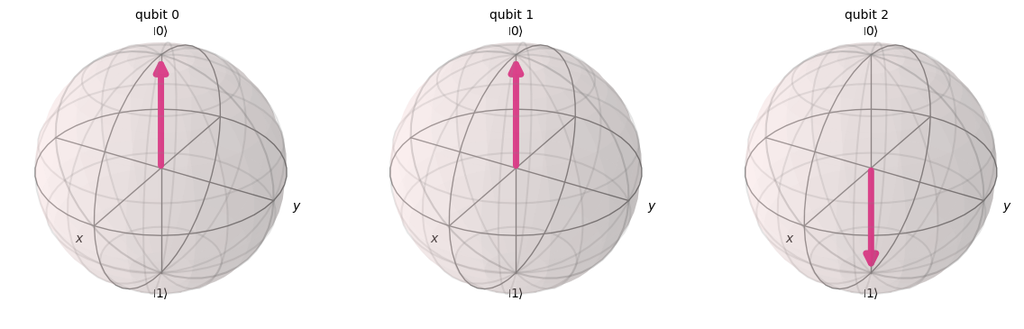

```python
num_qubits = 3
pos = 4
testStatevector = []
for i in range(8):
    testStatevector.append(0)
testStatevector[pos] = 1
print(testStatevector)
toReadBitOrderInQubits = Statevector(testStatevector)
plot_bloch_multivector(toReadBitOrderInQubits)
```

Now we are ready to proceed to run a test QFT routine.

```python
num_qubits = 4

q = QuantumRegister(num_qubits, "q")
c = ClassicalRegister(num_qubits, "c")
qft = QuantumCircuit(q,c)
```

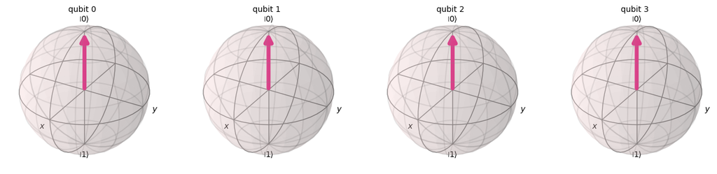

```python
qft_statevector1 = Statevector(qft)
plot_bloch_multivector(qft_statevector1)
```

```python
qft.x(q[0])
qft.x(q[1])
qft.x(q[3])

qft.draw()
```

```
     ┌───┐
q_0: ┤ X ├
     ├───┤
q_1: ┤ X ├
     └───┘
q_2: ─────
     ┌───┐
q_3: ┤ X ├
     └───┘
c: 4/═════
```

Note that the initialized qubit ($\ket{0}$) when transformed by the $X$ gate turns to the state $\ket{1}$.

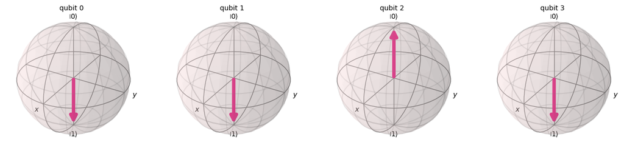

```python
qft_statevector2 = Statevector(qft)
plot_bloch_multivector(qft_statevector2)
```

```python
for j in reversed(range(num_qubits)):
    qft.h(j)
    for k in reversed(range(0, j)):
        phi = np.pi * (2.0 ** (k - j))
        qft.cp(phi, k, j) #controlled rotation gate for each qubit, check on k and rotate j
    qft.barrier()

qft.draw() # check that the circuit diagram is correct
```

```
     ┌───┐                                 ░                         ░      »
q_0: ┤ X ├────────────────────────■────────░────────────────■────────░──────»
     ├───┤                        │        ░                │        ░ ┌───┐»
q_1: ┤ X ├───────────────■────────┼────────░───────■────────┼────────░─┤ H ├»
     └───┘               │        │        ░ ┌───┐ │P(π/2)  │P(π/4)  ░ └───┘»
q_2: ───────────■────────┼────────┼────────░─┤ H ├─■────────■────────░──────»
     ┌───┐┌───┐ │P(π/2)  │P(π/4)  │P(π/8)  ░ └───┘                   ░      »
q_3: ┤ X ├┤ H ├─■────────■────────■────────░─────────────────────────░──────»
     └───┘└───┘                            ░                         ░      »
c: 4/═══════════════════════════════════════════════════════════════════════»
                                                                            »
«               ░ ┌───┐ ░
«q_0: ─■────────░─┤ H ├─░─
«      │P(π/2)  ░ └───┘ ░
«q_1: ─■────────░───────░─
«               ░       ░
«q_2: ──────────░───────░─
«               ░       ░
«q_3: ──────────░───────░─
«               ░       ░
«c: 4/════════════════════
«
```

Now, let’s extract the statevector and then see what it looks like.

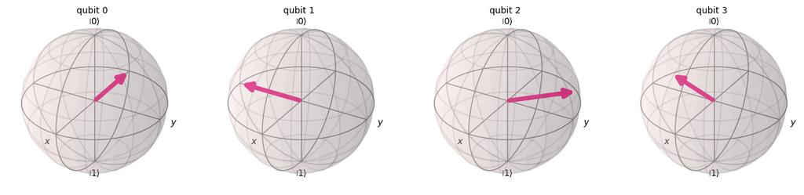

```python
qft_statevector3 = Statevector(qft)
plot_bloch_multivector(qft_statevector3)
```

We have not performed swap operations. Let's do that to finalize our result. You should be able to see the swap results visually at the end.

```python
for j in range(int(num_qubits/2)):
    qft.swap(j, (num_qubits-1) - j)
qft.draw()
```

```
     ┌───┐                                 ░                         ░      »
q_0: ┤ X ├────────────────────────■────────░────────────────■────────░──────»
     ├───┤                        │        ░                │        ░ ┌───┐»
q_1: ┤ X ├───────────────■────────┼────────░───────■────────┼────────░─┤ H ├»
     └───┘               │        │        ░ ┌───┐ │P(π/2)  │P(π/4)  ░ └───┘»
q_2: ───────────■────────┼────────┼────────░─┤ H ├─■────────■────────░──────»
     ┌───┐┌───┐ │P(π/2)  │P(π/4)  │P(π/8)  ░ └───┘                   ░      »
q_3: ┤ X ├┤ H ├─■────────■────────■────────░─────────────────────────░──────»
     └───┘└───┘                            ░                         ░      »
c: 4/═══════════════════════════════════════════════════════════════════════»
                                                                            »
«               ░ ┌───┐ ░
«q_0: ─■────────░─┤ H ├─░──X────
«      │P(π/2)  ░ └───┘ ░  │
«q_1: ─■────────░───────░──┼──X─
«               ░       ░  │  │
«q_2: ──────────░───────░──┼──X─
«               ░       ░  │
«q_3: ──────────░───────░──X────
«               ░       ░
«c: 4/══════════════════════════
«
```

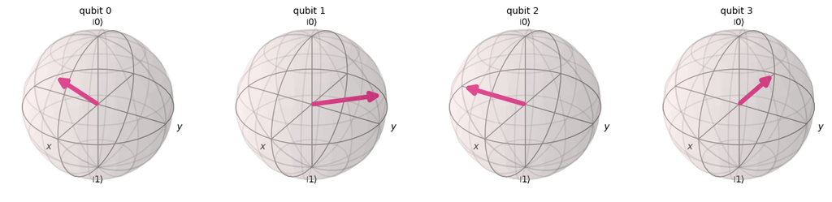

```python
qft_statevector4 = Statevector(qft)
plot_bloch_multivector(qft_statevector4)
```

Up to this point, you have seen the results of QFT, but you may feel that things do not really look like the conventional Fourier transform that you have known of in the past. In order to have such a sense, we have to restart from the classical Fourier tranform. Let us generate a sequence of some signal in the "time domain" with some noise: \begin{equation} f(t)= A_1 \sin{\omega_1 t} + A_2 \sin{\omega_2 t} + A_3 \epsilon(t) \end{equation}

```python
numSignalQubits = 10
omega1 = 2*np.pi* 0.020
omega2 = 2*np.pi* 0.007
A1 = 1.5
A2 = 3.0
A3 = 0.3
fSignal = []
for i in range(2**numSignalQubits):
    signal_t = A1 * np.sin(omega1 * i) + A2 * np.sin(omega2 * i) + A3 * np.random.rand()
    fSignal.append(signal_t)
```

One trick we need to do is to normalize the vector "fSignal". We do not need to do it classically, but in a later stage when we map the data into a quantum state, we need normalization. Besides, we can recover the original signal with the normalization constant if we need anyways.

```python
normSignal = np.linalg.norm(fSignal)
print("Normalizing with the norm of the signal: ", normSignal)
fSignal /= normSignal
```

```
Normalizing with the norm of the signal:  76.48584553424702
```

Now, we can plot the signal in time.

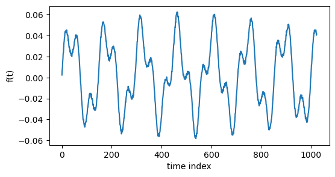

```python
import matplotlib.pyplot as plt
plt.figure(figsize=(6, 3))
plt.plot(fSignal, label="Signal")
plt.xlabel("time index")
plt.ylabel("f(t)")
plt.show()
```

Now we can perform discrete Fourier transform classically. Numpy provides a convenient functionality for that. Because Fourier transform uses exponential basis, for the plotting purpose, we need to take the real part or the absolute value.

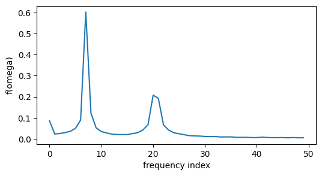

```python
omegaSignal = np.fft.fft(fSignal, norm="ortho")
plotData = np.abs(omegaSignal)
plt.figure(figsize=(6, 3))
plt.plot(plotData[0:50], label="Spectrum")
plt.xlabel("frequency index")
plt.ylabel("f(omega)")
plt.show()
```

In the above, you can see that there are two peaks that are broadened by the noise and some zero-frequency component that comes from the white noise.

Now that we saw the classical FFT results, we have to prepare the quantum computer such that the initial state matches the array fSignal. We need to understand that each position in the signal vector corresponds to a qubit state. Because there are 1024 data in the vector, we need 10 qubits to represent the vector. If the vector elements are $f_i$, the state you need to prepare is: \begin{equation} \ket{\psi} = \sum_i^N f_i \ket{x^i_0, x^i_1, \dots, x^i_{n-1}} \end{equation} and the $x^i_k$ values are chosen such that \begin{equation} 2^0 x^i_0 + 2^1 x^i_1 + 2^2 x^i_2 + \dots + 2^{n-1} x^i_{n-1} = i \end{equation} or $x^i_{n-1} \dots x^i_1 x^i_0$ is the binary representation of $i$ with $x^i_0$ representing the least significant bit. So the fSignal array simply becomes the state vector, in the basis of |00...0>, |10...0>, ..., |11...1>. How should we set the qubits to represent such an initial state? Qiskit provides a convenient function, but that's only for a virtual quantum computer. You cannot do it that easily on an actual machine where its initial state is |00...0>. For the purpose of learning QFT, let's forget about this practical issue and just run Qiskit function. Try to run the following two cells to see that QFT indeed generates the right spectrum. Although you will not feel the speed, the number of qubit operations is smaller than the number of classical FLOPs, although qubit operations on your virtual quantum computer will actually be slower than FFT.

```python
num_qubits = numSignalQubits

# prepare to match fSignal. This is impossible in actual quantum hardware where the initial state is just |00...0>
prepared_statevector = Statevector(fSignal)

qbits = QuantumRegister(num_qubits, "q")
cbits = ClassicalRegister(num_qubits, "c")
qft10 = QuantumCircuit(qbits,cbits)
qft10.initialize(prepared_statevector, range(0,num_qubits))
for j in reversed(range(num_qubits)):
    qft10.h(j)
    for k in reversed(range(0, j)):
        phi = np.pi / (2.0 ** (j - k))
        #controlled rotation gate for each qubit, k is control and j is target
        # (-) sign for phi is to change the engineers' convention into scientists' one
        qft10.cp(-phi, k, j)
    qft10.barrier()
for j in range(int(num_qubits/2)):
    qft10.swap(j, num_qubits-1-j)
qft10.draw()
```

```
      »
 q_0: »
      »
 q_1: »
      »
 q_2: »
      »
 q_3: »
      »
 q_4: »
      »
 q_5: »
      »
 q_6: »
      »
 q_7: »
      »
 q_8: »
      »
 q_9: »
      »
c: 10/»
      »
«      ┌────────────────────────────────────────────────────────────────────────────────────────────────────────────────────────────────────────────────────────────────────────────────────────────────────────────────────────────────────────────────────────────────────────────────────────────────────…
« q_0: ┤0                                                                                                                                                                                                                                                                                                   …
«      │                                                                                                                                                                                                                                                                                                    …
« q_1: ┤1                                                                                                                                                                                                                                                                                                   …
«      │                                                                                                                                                                                                                                                                                                    …
« q_2: ┤2                                                                                                                                                                                                                                                                                                   …
«      │                                                                                                                                                                                                                                                                                                    …
« q_3: ┤3                                                                                                                                                                                                                                                                                                   …
«      │                                                                                                                                                                                                                                                                                                    …
« q_4: ┤4                                                                                                                                                                                                                                                                                                   …
«      │  Initialize(0.002456,0.0076021,0.0092866,0.014747,0.017838,0.023134,0.023712,0.028137,0.032791,0.034577,0.03788,0.038635,0.043115,0.044054,0.043076,0.04378,0.044923,0.043236,0.043505,0.04545,0.043203,0.041631,0.040514,0.040858,0.039953,0.035156,0.036618,0.033848,0.030141,0.028698,0.029438,0…
« q_5: ┤5                                                                                                                                                                                                                                                                                                   …
«      │                                                                                                                                                                                                                                                                                                    …
« q_6: ┤6                                                                                                                                                                                                                                                                                                   …
«      │                                                                                                                                                                                                                                                                                                    …
« q_7: ┤7                                                                                                                                                                                                                                                                                                   …
«      │                                                                                                                                                                                                                                                                                                    …
```

[output cut: 198 more lines]

```
«            ░  │  │  │  │
« q_4: ──────░──┼──┼──┼──┼──X─
«            ░  │  │  │  │  │
« q_5: ──────░──┼──┼──┼──┼──X─
«            ░  │  │  │  │
« q_6: ──────░──┼──┼──┼──X────
«            ░  │  │  │
« q_7: ──────░──┼──┼──X───────
«            ░  │  │
« q_8: ──────░──┼──X──────────
«            ░  │
« q_9: ──────░──X─────────────
«            ░
«c: 10/═══════════════════════
«
```

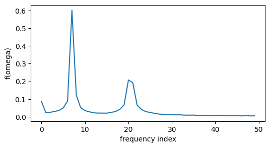

```
[0.0856081 +0.j         0.02268481-0.00461391j 0.02442432-0.00698696j ...
 0.02690571+0.01289782j 0.02442432+0.00698696j 0.02268481+0.00461391j]
[0.0856081 +0.j         0.02268481-0.00461391j 0.02442432-0.00698696j ...
 0.02690571+0.01289782j 0.02442432+0.00698696j 0.02268481+0.00461391j]
```

```python
final_statevector = Statevector(qft10)

plotData = np.abs(final_statevector.data)
plt.figure(figsize=(6, 3))
plt.plot(plotData[0:50], label="Spectrum")
plt.xlabel("frequency index")
plt.ylabel("f(omega)")
plt.show()
print(omegaSignal)
print(final_statevector.data)
```

By extracting the statevector in the four qubit example, we were able to observe how the phase manifests in the quantum state. Likewise, by extracting the statevector in the ten qubit example, we were able to see that QFT can do spectral analysis. However, a real quantum computer determines outcomes by performing measurements and obtaining probabilities but not by observing its wavefunction or the statevector. So, what results would we get if we measure the state above?

```python
qft10.measure(qbits,cbits)
#qft10.draw()
```

```
<qiskit.circuit.instructionset.InstructionSet at 0x7f6da2f5dc30>
```

```python
simulator = AerSimulator()
qft10 = transpile(qft10, simulator)
result = simulator.run(qft10, shots=10000).result()
```

```
{'0110101010': 1, '0000011001': 1, '1101101000': 1, '0010100111': 1, '1111100000': 2, '1110111110': 1, '0111101111': 1, '0010011100': 1, '0010111011': 1, '1010011000': 1, '0000110111': 1, '1111110001': 4, '0000100000': 2, '1111111111': 5, '0011111010': 1, '1111010101': 1, '1111100111': 2, '111011110…
```

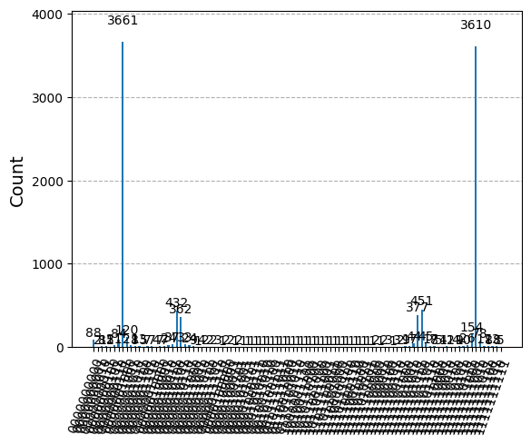

```python
counts = result.get_counts(qft10)
print(counts)
plot_histogram(counts)
```

As you can see, all data are now real numbers without any phase information. This may be enough for seeing a "spectrum" but may not be so in case we need all data including phase. Namely, unless we can see the details of the qubit wavefunction with the phase information, we cannot know the Fourier transform itself. Thus, QFT by itself is not useful *per se*, but it can be adopted as a component in many other algorithms. Those algorithms uses QFT results for useful purposes before actually performing measurements. Such algorithms also often have to adopt inverse Fourier transform, so we need to get familiarized with them.

# **2. Inverse QFT**

Because QFT is a simple unitary rotation of a vector, iQFT is another matrix-vector multiplication. Indeed, it is easy to understand that iQFT is \begin{equation} v_{k}=\frac{1}{\sqrt{N}} \sum_{j=0}^{N-1} e^{{\dfrac{2 \pi i}{N}} k j} \tilde{v}_{j} \equiv \sum_{k} U^{*}_{j k} \tilde{v}_{j} \end{equation} and we can see that a small change in the QFT routine can become inverse QFT. Often times, all gate operations are reversed.

To see its actual application, suppose we have the following statevector with a dimension $N = 64 = 2^6$. This vector was pre-generated with QFT without final swap operations. Thus, we will omit the leading swap part here.

```python
prepared_statevector = Statevector([ 1.25000000e-01+0.j        , -1.25000000e-01+0.j        ,
              7.65404249e-18+0.125j     , -7.65404249e-18-0.125j     ,
             -8.83883476e-02-0.08838835j,  8.83883476e-02+0.08838835j,
              8.83883476e-02-0.08838835j, -8.83883476e-02+0.08838835j,
              4.78354290e-02-0.11548494j, -4.78354290e-02+0.11548494j,
              1.15484942e-01+0.04783543j, -1.15484942e-01-0.04783543j,
             -1.15484942e-01+0.04783543j,  1.15484942e-01-0.04783543j,
             -4.78354290e-02-0.11548494j,  4.78354290e-02+0.11548494j,
             -1.03933702e-01+0.06944628j,  1.03933702e-01-0.06944628j,
             -6.94462791e-02-0.1039337j ,  6.94462791e-02+0.1039337j ,
              1.22598160e-01+0.02438629j, -1.22598160e-01-0.02438629j,
             -2.43862903e-02+0.12259816j,  2.43862903e-02-0.12259816j,
              2.43862903e-02+0.12259816j, -2.43862903e-02-0.12259816j,
             -1.22598160e-01+0.02438629j,  1.22598160e-01-0.02438629j,
              6.94462791e-02-0.1039337j , -6.94462791e-02+0.1039337j ,
              1.03933702e-01+0.06944628j, -1.03933702e-01-0.06944628j,
             -3.62855847e-02-0.11961754j,  3.62855847e-02+0.11961754j,
              1.19617542e-01-0.03628558j, -1.19617542e-01+0.03628558j,
             -5.89245921e-02+0.11024016j,  5.89245921e-02-0.11024016j,
             -1.10240158e-01-0.05892459j,  1.10240158e-01+0.05892459j,
             -1.24398091e-01-0.01225214j,  1.24398091e-01+0.01225214j,
              1.22521425e-02-0.12439809j, -1.22521425e-02+0.12439809j,
              7.92991605e-02+0.09662631j, -7.92991605e-02-0.09662631j,
             -9.66263067e-02+0.07929916j,  9.66263067e-02-0.07929916j,
              9.66263067e-02+0.07929916j, -9.66263067e-02-0.07929916j,
             -7.92991605e-02+0.09662631j,  7.92991605e-02-0.09662631j,
             -1.22521425e-02-0.12439809j,  1.22521425e-02+0.12439809j,
              1.24398091e-01-0.01225214j, -1.24398091e-01+0.01225214j,
              1.10240158e-01-0.05892459j, -1.10240158e-01+0.05892459j,
              5.89245921e-02+0.11024016j, -5.89245921e-02-0.11024016j,
             -1.19617542e-01-0.03628558j,  1.19617542e-01+0.03628558j,
              3.62855847e-02-0.11961754j, -3.62855847e-02+0.11961754j])
```

The inverse QFT applied to the given state is below.

```python
num_qubits = 6
iqft = QuantumCircuit(num_qubits)
iqft.initialize(prepared_statevector, range(0,num_qubits))
```

```
<qiskit.circuit.instructionset.InstructionSet at 0x7f6da92e2290>
```

```python
## initial swap omitted intentionally
#for j in range(int(num_qubits/2)):
#    iqft.swap(j, (num_qubits-1) - j)
for j in range(num_qubits):
    for k in range(0, j):
        lam = np.pi * (-2.0 ** (k - j))
        iqft.cp(lam, j, k)
    iqft.h(j)
    iqft.barrier()
```

```python
iqft.measure_all()
iqft.draw()
```

```
        »
   q_0: »
        »
   q_1: »
        »
   q_2: »
        »
   q_3: »
        »
   q_4: »
        »
   q_5: »
        »
meas: 6/»
        »
«        ┌──────────────────────────────────────────────────────────────────────────────────────────────────────────────────────────────────────────────────────────────────────────────────────────────────────────────────────────────────────────────────────────────────────────────────────────────────…
«   q_0: ┤0                                                                                                                                                                                                                                                                                                 …
«        │                                                                                                                                                                                                                                                                                                  …
«   q_1: ┤1                                                                                                                                                                                                                                                                                                 …
«        │                                                                                                                                                                                                                                                                                                  …
«   q_2: ┤2                                                                                                                                                                                                                                                                                                 …
«        │  Initialize(0.125,-0.125,0.125j,-0.125j,-0.088388-0.088388j,0.088388+0.088388j,0.088388-0.088388j,-0.088388+0.088388j,0.047835-0.11548j,-0.047835+0.11548j,0.11548+0.047835j,-0.11548-0.047835j,-0.11548+0.047835j,0.11548-0.047835j,-0.047835-0.11548j,0.047835+0.11548j,-0.10393+0.069446j,0.10…
«   q_3: ┤3                                                                                                                                                                                                                                                                                                 …
«        │                                                                                                                                                                                                                                                                                                  …
«   q_4: ┤4                                                                                                                                                                                                                                                                                                 …
«        │                                                                                                                                                                                                                                                                                                  …
«   q_5: ┤5                                                                                                                                                                                                                                                                                                 …
«        └──────────────────────────────────────────────────────────────────────────────────────────────────────────────────────────────────────────────────────────────────────────────────────────────────────────────────────────────────────────────────────────────────────────────────────────────────…
«meas: 6/═══════════════════════════════════════════════════════════════════════════════════════════════════════════════════════════════════════════════════════════════════════════════════════════════════════════════════════════════════════════════════════════════════════════════════════════════════…
«                                                                                                                                                                                                                                                                                                           …
«        ┌───┐ ░                 ░                           ░           »
«   q_0: ┤ H ├─░──■──────────────░──■────────────────────────░──■────────»
«        └───┘ ░  │P(-π/2) ┌───┐ ░  │                        ░  │        »
«   q_1: ──────░──■────────┤ H ├─░──┼─────────■──────────────░──┼────────»
«              ░           └───┘ ░  │P(-π/4)  │P(-π/2) ┌───┐ ░  │        »
«   q_2: ──────░─────────────────░──■─────────■────────┤ H ├─░──┼────────»
«              ░                 ░                     └───┘ ░  │P(-π/8) »
«   q_3: ──────░─────────────────░───────────────────────────░──■────────»
«              ░                 ░                           ░           »
«   q_4: ──────░─────────────────░───────────────────────────░───────────»
```

[output cut: 35 more lines]

```
«         ░ ┌─┐
«   q_0: ─░─┤M├───────────────
«         ░ └╥┘┌─┐
«   q_1: ─░──╫─┤M├────────────
«         ░  ║ └╥┘┌─┐
«   q_2: ─░──╫──╫─┤M├─────────
«         ░  ║  ║ └╥┘┌─┐
«   q_3: ─░──╫──╫──╫─┤M├──────
«         ░  ║  ║  ║ └╥┘┌─┐
«   q_4: ─░──╫──╫──╫──╫─┤M├───
«         ░  ║  ║  ║  ║ └╥┘┌─┐
«   q_5: ─░──╫──╫──╫──╫──╫─┤M├
«         ░  ║  ║  ║  ║  ║ └╥┘
«meas: 6/════╩══╩══╩══╩══╩══╩═
«            0  1  2  3  4  5
```

```python
simulator = AerSimulator()
iqft = transpile(iqft, simulator)
result = simulator.run(iqft,shots=10000).result()
counts = result.get_counts(iqft)
print(counts)
```

```
{'101101': 10000}
```